# ConSciR: An R package for Conservation Science data

14 April 2026

# Summary

`ConSciR` is an R package (Team 2024) designed for cultural heritage conservation, providing tools for preventive conservation data analysis (Cosaert and Beltran 2022). `ConSciR` streamlines workflows across museums, galleries, and heritage sites by offering humidity calculations, conservation risk assessments, and sustainability metrics (Cosaert et al. 2023). The package contains a useful set of calculations for conservators, engineers, scientists, and data scientists to manage environmental data, understand risks to heritage collections, and develop custom analytical communication tools in the R environment. In line with the FAIR principles, `ConSciR` is intended to evolve alongside emerging conservation science research and user feedback.

# Statement of need

Preventive conservation relies on managing environmental risks such as humidity, temperature, light, pests, and pollutants. Modern heritage management increasingly involves analysing large environmental time-series datasets to make sound data-driven decisions (Cosaert 2021). Existing workflows typically require manual data tidying and knowledge of how to encode, often tedious, physical chemistry, mechanical, biology and thermodynamic calculations (Cosaert et al. 2023). Pre-compiled tools have been developed for these tasks, but these are either paid-for services, spreadsheet-based, not open-source, provide only single data point calculations or have been deprecated (“Dew Point Calculator” n.d.; “eClimateNotebook” n.d.; Padfield 2010; Smulders 2014; Kupczak et al. 2018; Pretzel 2023; Vaisala n.d.). There is a gap for an open-source package of commonly used calculations for conservation to create their own bespoke tools in order to adhere to preventive conservation standards (Taylor et al. 2023). This is highlighted in the 2022 Getty Conservation Institute’s Tools paper (Cosaert and Beltran 2022), for the need for practical, user-friendly, cost-efficient, and decision-oriented tools for environmental monitoring. `ConSciR` is a step towards meeting conservation needs by consolidating environmental data cleaning, preservation metrics and calculations into a single R package. Interactive Shiny applications (Chang et al. 2024) are included for quick data visualisation for users without prior training in coding.

# Features

The functions in `ConSciR` are grouped into three themes: humidity calculations, conservation tools, and sustainability metrics. These address heritage needs for environmental analysis, risk assessment for material damage, as well as metrics for estimating the costs of mitigation, especially at a time when energy efficiency is important for heritage organisations. Humidity functions are used to determine the relationship between temperature and moisture in air, helping conservators, scientists, and engineers understand damage to moisture-sensitive materials and manage air-conditioning systems. Humidity calculations for dew point, absolute humidity, humidity ratio, air density, and vapour pressure (Buck 1981; Wagner and Pruß 2002) accept time-series datasets in formats commonly collected by heritage organisations (Date, Temperature and Humidity in columns). While some but not all of these calculations are currently available in R using the humidity (Cai 2019) and IAPWS95 (Baptista 2025) packages, calculating these variables typically requires knowledge of physical chemistry when using these packages. Humidity calculations have been checked for accuracy against the IAPWS95 dataset (Baptista 2025), VAISALA online calculator (Vaisala n.d.) and for stability using the testthat framework (Wickham 2011).

To facilitate workflow integration, tidying functions are also provided for formatting industry-standard sensor outputs. Psychrometric charts and graphical outputs are included for visualisation of the humidity functions. The conservation tools offer object damage calculations, for example, models for mould growth (Hukka and Viitanen 1999; Viitanen et al. 2015; Zeng et al. 2023) and lifetime estimates for organic materials (Michalski 2013). Sustainability metrics are being added through consultation and as they are being developed through research.

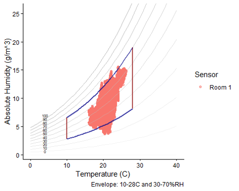

Psychrometric chart

# Usage

A small but growing group of coders in cultural heritage conservation includes environmental monitoring specialists, scientists, preventive conservators, and building engineers. These users benefit from the tools provided by `ConSciR`, which is designed for two key user groups: research data managers and domain-specific coders (Cosaert et al. 2025). Research data managers, who typically have advanced coding experience, can use the package’s functions to build large-scale applications on complex datasets. Domain-specific coders can use the functions as a toolset for answering conservation-related questions and automating routine data tasks. To support users, articles are available online (https://bhavshah01.github.io/ConSciR). These examples provide conservation educators and trainers with resources to teach coding alongside conservation theory (Beltran, Linden, and Cosaert 2025).

The structure of `ConSciR` enables users to address a range of preventive conservation questions within a single, reproducible analytical framework, benefiting from the full array of tools available in R. The package’s functions support queries such as calculating dew point, comparing environmental risks between spaces, scenario analysis for changing HVAC setpoints, and evaluating climate change impacts (Shah and Long 2025). By integrating these functions, `ConSciR` aims to support collection care and preventive conservation.

A Shiny application for users also accompanies the package https://oceanonline.shinyapps.io/ConSciR/

# Acknowledgements

We acknowledge contributions from and would like to thank Emily R. Long, Marcin Zygmunt, Hebe Halstead, Avery Bazemore, Josep Grau-Bové, Scott Allan Orr, Seka Seneviratne, Jenny Kim, Èlia Batlle, Rose King and David Thickett for the development of the `ConSciR` package.

# References

Baptista, Benedito. 2025. *IAPWS95: Thermophysical Properties of Water and Steam*. https://doi.org/10.32614/CRAN.package.IAPWS95.

Beltran, Vincent Laudato, Jeremy Linden, and Annelies Cosaert. 2025. “Developing Conservation-Focused Curriculum to Advance Analysis of Temperature and Relative Humidity Data.” In *Collection Care: Environmental Monitoring, Risk Assessment and Risk Management*, edited by Ángel F. Perles-Ivars, Laura Fuster-López, and Emanuela Bosco, 3–13. Springer Proceedings in Archaeology and Heritage. Cham: Springer Nature Switzerland. https://doi.org/10.1007/978-3-031-85655-6\_1.

Buck, Arden L. 1981. “New Equations for Computing Vapor Pressure and Enhancement Factor.” *Journal of Applied Meteorology* 20 (12): 1527–32. https://doi.org/10.1175/1520-0450(1981)020<1527:NEFCVP>2.0.CO;2.

Cai, Jun. 2019. *Humidity: Calculate Water Vapor Measures from Temperature and Dew Point*. https://github.com/caijun/humidity.

Chang, Winston, Joe Cheng, JJ Allaire, Carson Sievert, Barret Schloerke, Yihui Xie, Jeff Allen, Jonathan McPherson, Alan Dipert, and Barbara Borges. 2024. “Shiny: Web Application Framework for r.” *The R Foundation*. https://doi.org/10.32614/cran.package.shiny.

Cosaert, Annelies. 2021. “Comparison of Temperature and Relative Humidity Analysis Tools to Address Practitioner Needs and Improve Decision-Making.” In *ICOM-CC 19thTriennial Conference Preprints, Beijing*, edited by J Bridgland. Paris: International Council of Museums. https://www.icom-cc-publications-online.org/4433/Comparison-of-temperature-and-relative-humidity-analysis-tools-to-address-practitioner-needs-and-improve-decision-making.

Cosaert, Annelies, and Vincent L Beltran. 2022. *Tools for the Analysis of Collection Environments: Lessons Learned and Future Development*. Getty Conservation Institute.

Cosaert, Annelies, Renaud Gérard, Alexandre Mayer, and Olivier Deparis. 2023. “A Comparison of Preservation Metrics Expressing Mechanical, Chemical and Biological Damages.” In *ICOM-CC 20th Triennial Conference : Working Towards a Sustainable Past Preprints*, edited by JEditor Bridgland, 1406. International Council of Museums.

Cosaert, Annelies, Bhavesh Shah, Clara Penagos, Wim Fremout, Nicolas Nadisic, Roald Hayen, Sebastiaan Godts, and Stephanie Buyle. 2025. “Preserving for Eternity, Coding for Today: The Role of Pseudo-Developers in Cultural Heritage Institutions.” In *Proceedings of International Speakers*, edited by Mingxin Ma and YimingTranslators Li, 81–141. National Museum of China.

“Dew Point Calculator.” n.d. WEBSITE. Accessed March 7, 2025. https://www.dpcalc.org/.

“eClimateNotebook.” n.d. WEBSITE. Accessed March 27, 2025. https://www.imagepermanenceinstitute.org/environmental-management/eclimatenotebook.

Hukka, A., and H. A. Viitanen. 1999. “A Mathematical Model of Mould Growth on Wooden Material.” *Wood Science and Technology* 33 (6): 475–85. https://doi.org/10.1007/s002260050131.

Kupczak, Arkadiusz, Mariusz Jędrychowski, Marcin Strojecki, Leszek Krzemień, Łukasz Bratasz, Michał Łukomski, and Roman Kozłowski. 2018. “HERIe: A Web-Based Decision-Supporting Tool for Assessing Risk of Physical Damage Using Various Failure Criteria.” *Studies in Conservation* 63 (sup1): 151–55. https://doi.org/10.1080/00393630.2018.1504447.

Michalski, S. 2013. “Stuffing Everything We Know about Mechanical Properties into One Collection Simulation.” In, edited by Jonathan Ashley-Smith, Andreas Burmester, and Melanie Eibl, 349–62. London, UK: Archetype. https://archetype.co.uk/our-titles/climate-for-collections-standards-and-uncertainties/?id=185.

Padfield, Tim. 2010. “Conservation Physics: Calculator for Energy Use in Museums.” *Calculator for Energy Use in Museums*. https://www.conservationphysics.org/atmcalc/energyusecalc.html.

Pretzel, Boris. 2023. “The Climate Toolboxmicrosoftexcelbased Tool for Assessing and Comparing the Effects of Internal Climates on Museum Artefacts.” *Heritage* 6 (4): 3745–56. https://doi.org/10.3390/heritage6040198.

Shah, Bhavesh, and Emily R Long. 2025. “Harnessing Data Science Technology for Environmental Monitoring at the v&a.” In *Collection Care: Environmental Monitoring, Risk Assessment and Risk Management*, edited by Ángel F. Perles-Ivars, Laura Fuster-López, and Emanuela Bosco, 45–56. Springer Proceedings in Archaeology and Heritage. Cham: Springer Nature Switzerland. https://doi.org/10.1007/978-3-031-85655-6\_5.

Smulders, H. 2014. “Physics of Monuments: Online Applications.” Edited by M Martens. *Technical University of Eindhoven*. http://www.monumenten.bwk.tue.nl/Algemeen/Applicaties.aspx.

Taylor, Joel, Michael C Henry, Vincent Laudato Beltran, Walt Crimm, Matthew Eckelman, Jane Henderson, Jeremy Linden, et al. 2023. *Managing Collection Environments: Technical Notes and Guidance*. Edited by Joel Taylor and Vincent Laudato Beltran. Guidelines. Getty Conservation Institute.

Team, R Core. 2024. “R: A Language and Environment for Statistical Computing.” OTHER. Vienna, Austria. https://www.R-project.org/.

Vaisala. n.d. “Vaisala Humidity Calculator.” WEBSITE. *Vaisala Humidity Calculator*. Accessed August 1, 2025. https://www.vaisala.com/en/calculators/humidity-calculator.

Viitanen, H., M. Krus, T. Ojanen, V. Eitner, and D. Zirkelbach. 2015. “Mold Risk Classification Based on Comparative Evaluation of Two Established Growth Models.” *Energy Procedia* 78 (November): 1425–30. https://doi.org/10.1016/j.egypro.2015.11.165.

Wagner, W, and A Pruß. 2002. “The IAPWS Formulation 1995 for the Thermodynamic Properties of Ordinary Water Substance for General and Scientific Use.” *Journal of Physical and Chemical Reference Data* 31 (2): 387–535. https://doi.org/10.1063/1.1461829.

Wickham, Hadley. 2011. “Testthat: Get Started with Testing.” *The R Journal* 3: 5–10. https://journal.r-project.org/archive/2011-1/RJournal_2011-1_Wickham.pdf.

Zeng, Lingjie, Yuqing Chen, Mingyao Ma, Bowen Du, Jun Gao, Guoqing Cao, and Jingguang Li. 2023. “Prediction of Mould Growth Rate Within Building Envelopes: Development and Validation of an Improved Model.” *Building Services Engineering Research and Technology* 44 (1): 63–79. https://doi.org/10.1177/01436244221137846.